# PPO Training Walkthrough for Qwen2.5-1.5B

This notebook provides a comprehensive walkthrough of the PPO (Proximal Policy Optimization) training pipeline for fine-tuning the Qwen2.5-1.5B language model with sentiment-based rewards.

**Contents:**

1. Model Setup - Understanding the three model instances
2. Sequence Indexing & Masks - Visualizing prompt/response/padding masks
3. Reward Tensor Alignment - How rewards map to sequence positions
4. Learning Curves - Training progress from metrics.jsonl
5. Base vs Aligned Model - Comparing generation before/after training

```python
import sys
sys.path.insert(0, '/workspace/src')

import json
import torch
import numpy as np
import pandas as pd
import matplotlib.pyplot as plt
import seaborn as sns

from qwen_ppo_tuning.config import GenerationConfig, PPOConfig
from qwen_ppo_tuning.models import QwenModel, PolicyQwenModel, ReferenceQwenModel, QwenModelValueHead
from qwen_ppo_tuning.rewarder import SentimentRewarder
from qwen_ppo_tuning.utils import pad_sequences, logprobs_from_logits

plt.style.use('seaborn-v0_8-darkgrid')
%matplotlib inline
```

## 1. Model Architecture Overview

The PPO training setup requires **three model instances**:

```
SetupQwenModel (base: loads weights, creates tokenizer/optimizer)
├── QwenModel (adds generation logic with/without KV cache)
│   ├── PolicyQwenModel (trainable, requires_grad=True)
│   └── ReferenceQwenModel (frozen, provides KL baseline)
└── QwenModelValueHead (adds linear value head for advantage estimation)
```

- **PolicyQwenModel**: The model being trained. Generates text and its parameters are updated via PPO.
- **ReferenceQwenModel**: Frozen copy of the initial model. Used to compute KL divergence penalty to prevent the policy from drifting too far.
- **QwenModelValueHead**: Predicts state values V(s) for computing advantages in GAE.

```python
# Model paths
BASE_MODEL_PATH = "/workspace/base_models/Qwen2.5-1.5B"
ALIGNED_MODEL_PATH = "/workspace/ppo_outputs/kv-cache/policy_model.pt"

# Load a base model for demonstration
print("Loading base QwenModel...")
base_model = QwenModel(model_path=BASE_MODEL_PATH)
print(f"Model loaded on device: {base_model.device}")
print(f"Vocabulary size: {base_model.tokenizer.vocab_size:,}")
print(f"Max sequence length: {base_model.block_size:,}")
```

```
Loading base QwenModel...
Model loaded on device: cuda
Vocabulary size: 151,643
Max sequence length: 128,000
```

```python
# Load the reward model
print("Loading SentimentRewarder...")
rewarder = SentimentRewarder()
print(f"Reward model: {rewarder.model.config._name_or_path}")
print(f"Label mapping: {rewarder.LABEL_MAP}")
```

```
Loading SentimentRewarder...
```

[output not shown]

```
Reward model: cardiffnlp/twitter-roberta-base-sentiment-latest
Label mapping: {'negative': -1.0, 'neutral': 0.1, 'positive': 10.0}
```

## 2. Understanding Sequence Indexing & Masks: The Action Perspective

A critical aspect of PPO for language models is understanding that **masks represent actions, not token membership**.

### The Key Insight: Actions, Not Tokens

In autoregressive language modeling, each position represents an **action** (choosing the next token based on the current context). The mask at position `i` tells us what **type of token was generated** by the action at position `i`.

```
Tokens:      [I] [think] [the] [movie] [was] [great] [!] [<EOS>] [<PAD>]
Positions:    0     1      2      3      4      5     6     7       8
```

When we compute masks (shifted by 1 to align with log probabilities):

```
Position i:     0      1      2      3      4      5      6      7
Input token:   [I]  [think] [the] [movie] [was] [great]  [!]  [<EOS>]
      ↓         ↓      ↓      ↓      ↓      ↓      ↓      ↓      ↓
Generated:   [think] [the] [movie] [was] [great]  [!]  [<EOS>] [???]
```

### Why "was" has response_mask=1

For the prompt "I think the movie was":

- Position 4 corresponds to inputting "was" → generating "great" (first response token)
- **"was" has response_mask=1** not because "was" is part of the response, but because **inputting "was" led to generating a response token**

### Why EOS has response_mask=0

- The EOS token at position 7 is the **last generated token**
- Position 7 would mean: input EOS → generate next token
- But EOS terminates generation, so **no response token was generated**
- Therefore, **EOS has response_mask=0** even though it IS part of the response

### Visual Summary

```
"I think the movie was" → "great ! <EOS>"

Mask semantics (at position i):
┌─────────────────────────────────────────────────────────────────┐
│ prompt_mask[i]=1   → inputting token[i] generated a PROMPT token    │
│ response_mask[i]=1 → inputting token[i] generated a RESPONSE token  │
│ padding_mask[i]=1  → position i is padding (no real token)          │
└─────────────────────────────────────────────────────────────────┘
```

Let's visualize this with real data.

```python
# Generate some sample outputs to examine masks
prompts = [
    "I think the movie was",
    "The restaurant experience was",
    "Overall, I felt that",
]

gen_config = GenerationConfig(
    max_new_tokens=30,
    temperature=0.8,
    top_k=50,
    use_kv_cache=False,  # Simpler for demonstration
)

print("Generating sample outputs...\n")
outputs = []
for prompt in prompts:
    output = base_model.generate(prompt, config=gen_config)
    outputs.append(output)
    print(f"Prompt: {output['input_text']}")
    print(f"Response: {output['response_text']}")
    print(f"Input length: {output['input_length']}, Response length: {output['generated_response_length']}")
    print("-" * 60)
```

```
Generating sample outputs...

Prompt: I think the movie was
Response:  good, it was ________ to watch.
A. too exciting to be
B. too exciting be
C. enough exciting to be
D
Input length: 5, Response length: 30
------------------------------------------------------------
Prompt: The restaurant experience was
Response:  amazing. The food was great.  The service was outstanding.  I will be back and will recommend to others.
Choose: was this review given
Input length: 4, Response length: 30
------------------------------------------------------------
Prompt: Overall, I felt that
Response:  this was a very enjoyable read. It had a nice pace to it and the story line was interesting. I'm glad that I decided to read this
Input length: 5, Response length: 30
------------------------------------------------------------
```

```python
# Get batched response properties (this computes masks)
response_props = base_model.get_batched_response_properties(outputs, pad_to=64)

print("Response properties shapes:")
print(f"  padded_generated_ids: {response_props['padded_generated_ids'].shape}")
print(f"  logprobs: {response_props['logprobs'].shape}")
print(f"  prompt_mask: {response_props['prompt_mask'].shape}")
print(f"  response_mask: {response_props['response_mask'].shape}")
print(f"  padding_mask: {response_props['padding_mask'].shape}")
```

```
Response properties shapes:
  padded_generated_ids: torch.Size([3, 64])
  logprobs: torch.Size([3, 63])
  prompt_mask: torch.Size([3, 63])
  response_mask: torch.Size([3, 63])
  padding_mask: torch.Size([3, 63])
```

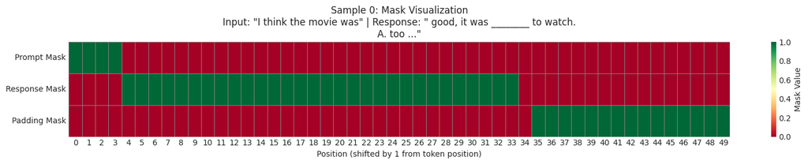

```python
def visualize_masks(response_props, outputs, sample_idx=0, max_tokens=50):
    """
    Create a heatmap visualization of the different masks for a single sample.
    """
    prompt_mask = response_props['prompt_mask'][sample_idx].numpy()[:max_tokens]
    response_mask = response_props['response_mask'][sample_idx].numpy()[:max_tokens]
    padding_mask = response_props['padding_mask'][sample_idx].numpy()[:max_tokens]

    # Stack masks for visualization
    mask_matrix = np.stack([
        prompt_mask.astype(float),
        response_mask.astype(float),
        padding_mask.astype(float),
    ])

    fig, ax = plt.subplots(figsize=(16, 3))

    # Create heatmap
    sns.heatmap(
        mask_matrix,
        ax=ax,
        cmap='RdYlGn',
        cbar_kws={'label': 'Mask Value'},
        yticklabels=['Prompt Mask', 'Response Mask', 'Padding Mask'],
        xticklabels=range(max_tokens),
        linewidths=0.5,
        linecolor='gray',
    )

    # Add token labels on top
    tokens = response_props['padded_generated_ids'][sample_idx].tolist()[:max_tokens+1]
    token_strs = [base_model.tokenizer.decode([t]) for t in tokens]

    ax.set_xlabel('Position (shifted by 1 from token position)')
    ax.set_title(f'Sample {sample_idx}: Mask Visualization\n'
                 f'Input: "{outputs[sample_idx]["input_text"]}" | '
                 f'Response: "{outputs[sample_idx]["response_text"][:40]}..."')

    plt.tight_layout()
    return fig

# Visualize masks for first sample
fig = visualize_masks(response_props, outputs, sample_idx=0)
plt.show()
```

[figure not shown]

```python
def visualize_action_perspective(response_props, outputs, sample_idx=0, max_display=20):
    """
    Visualize the INPUT → OUTPUT relationship to clarify mask semantics.
    Shows that masks indicate what TYPE of token was GENERATED by each action.
    """
    # Get tokens
    all_tokens = response_props['padded_generated_ids'][sample_idx].tolist()
    input_len = outputs[sample_idx]['input_length']
    response_len = outputs[sample_idx]['generated_response_length']
    total_len = input_len + response_len

    # Limit display to keep it readable
    display_len = min(total_len + 2, max_display)

    # Decode tokens
    token_strs = [base_model.tokenizer.decode([t]).replace('\n', '↵').strip() or '·'
                  for t in all_tokens[:display_len + 1]]

    # Get masks (these are shifted by 1)
    prompt_mask = response_props['prompt_mask'][sample_idx].numpy()
    response_mask = response_props['response_mask'][sample_idx].numpy()
    padding_mask = response_props['padding_mask'][sample_idx].numpy()

    fig = plt.figure(figsize=(18, 14))

    # === Panel 1: Input → Output Flow (top) ===
    ax1 = fig.add_axes([0.05, 0.55, 0.9, 0.40])  # [left, bottom, width, height]
    ax1.set_xlim(-1.5, display_len + 0.5)
    ax1.set_ylim(-1, 3.5)

    # Title
    ax1.set_title(f'Action Perspective: Input Token → Generated Token\n'
                  f'Prompt: "{outputs[sample_idx]["input_text"]}" → '
                  f'Response: "{outputs[sample_idx]["response_text"][:35]}..."',
                  fontsize=12, fontweight='bold', pad=10)

    # Draw input tokens (top row) and output tokens (bottom row) with arrows
    for i in range(display_len):
        # Determine input token color based on its TYPE
        if i < input_len:
            in_color = 'steelblue'
        elif i < total_len:
            in_color = 'seagreen'
        else:
            in_color = 'lightgray'

        # Input token box (top)
        rect = plt.Rectangle((i - 0.4, 2.4), 0.8, 0.7,
                              facecolor=in_color, edgecolor='black', linewidth=1.5)
        ax1.add_patch(rect)
        ax1.text(i, 2.75, token_strs[i][:7], ha='center', va='center',
                fontsize=9, fontweight='bold', color='white' if in_color != 'lightgray' else 'black')
        ax1.text(i, 2.2, f'[{i}]', ha='center', va='center', fontsize=7, color='gray')

        # Arrow from input to output
        ax1.annotate('', xy=(i, 1.4), xytext=(i, 2.3),
                    arrowprops=dict(arrowstyle='->', color='#555555', lw=2))

        # Output token (what was GENERATED by this action) - bottom row
        output_idx = i + 1
        if output_idx < len(token_strs):
            # Color based on what TYPE of token was generated (this determines the mask!)
            if i < input_len - 1:  # Generated a prompt token
                out_color = 'steelblue'
                mask_type = 'P'
            elif i < total_len - 1:  # Generated a response token
                out_color = 'seagreen'
                mask_type = 'R'
            else:
                out_color = 'lightgray'
                mask_type = '-'

            rect = plt.Rectangle((i - 0.4, 0.6), 0.8, 0.7,
                                  facecolor=out_color, edgecolor='black', linewidth=1.5, alpha=0.8)
            ax1.add_patch(rect)
            ax1.text(i, 0.95, token_strs[output_idx][:7], ha='center', va='center',
                    fontsize=9, fontweight='bold', color='white' if out_color != 'lightgray' else 'black')

            # Mask indicator below
            mask_color = 'darkgreen' if mask_type == 'R' else ('darkblue' if mask_type == 'P' else 'gray')
            ax1.text(i, 0.25, f'mask={mask_type}', ha='center', va='center',
                    fontsize=7, color=mask_color, fontweight='bold')

    # Labels on the left
    ax1.text(-1.2, 2.75, 'INPUT\ntoken[i]', ha='center', va='center', fontsize=10, fontweight='bold')
    ax1.text(-1.2, 0.95, 'OUTPUT\ntoken[i+1]', ha='center', va='center', fontsize=10, fontweight='bold')
    ax1.text(-1.2, 0.25, 'MASK\nat pos i', ha='center', va='center', fontsize=8, fontweight='bold', color='gray')

    ax1.axis('off')

    # === Panel 2: Legend and Key Insight (middle) ===
    ax2 = fig.add_axes([0.05, 0.38, 0.9, 0.12])
    ax2.set_xlim(0, 10)
    ax2.set_ylim(0, 2)

    # Legend boxes
    legend_items = [
        (0.5, 'steelblue', 'P = prompt_mask=1', '(action generated a PROMPT token)'),
        (3.5, 'seagreen', 'R = response_mask=1', '(action generated a RESPONSE token)'),
        (7.0, 'lightgray', '- = padding/no action', '(no token generated)'),
    ]

    for x, color, label1, label2 in legend_items:
        rect = plt.Rectangle((x, 0.8), 0.4, 0.8, facecolor=color, edgecolor='black', linewidth=1)
        ax2.add_patch(rect)
        ax2.text(x + 0.6, 1.2, label1, ha='left', va='center', fontsize=10, fontweight='bold')
        ax2.text(x + 0.6, 0.7, label2, ha='left', va='center', fontsize=9, color='gray')

    ax2.axis('off')

    # === Panel 3: Key Examples with Explanations (bottom) ===
    ax3 = fig.add_axes([0.05, 0.02, 0.9, 0.32])
    ax3.set_xlim(0, 10)
    ax3.set_ylim(0, 4)

    # Boundary position explanation (left side)
    boundary_pos = input_len - 1
    ax3.add_patch(plt.Rectangle((0.3, 2.2), 4.2, 1.6, facecolor='#ffffcc',
                                  edgecolor='#cc9900', linewidth=2, alpha=0.9))
    ax3.text(2.4, 3.5, f'WHY "{token_strs[boundary_pos]}" HAS response_mask=1',
             ha='center', va='center', fontsize=11, fontweight='bold', color='#806600')
    ax3.text(2.4, 2.95, f'Position {boundary_pos}: token "{token_strs[boundary_pos]}" is the LAST prompt token',
             ha='center', va='center', fontsize=9)
    ax3.text(2.4, 2.55, f'When we INPUT "{token_strs[boundary_pos]}", we GENERATE "{token_strs[boundary_pos+1]}" (first response)',
             ha='center', va='center', fontsize=9, fontweight='bold', color='darkgreen')

    # EOS explanation (right side)
    eos_pos = min(total_len - 1, display_len - 1)
    ax3.add_patch(plt.Rectangle((5.3, 2.2), 4.4, 1.6, facecolor='#ffe6cc',
                                  edgecolor='#cc6600', linewidth=2, alpha=0.9))
    ax3.text(7.5, 3.5, 'WHY <EOS> HAS response_mask=0',
             ha='center', va='center', fontsize=11, fontweight='bold', color='#804000')
    ax3.text(7.5, 2.95, f'Position {eos_pos}: <EOS> is the LAST generated token',
             ha='center', va='center', fontsize=9)
    ax3.text(7.5, 2.55, 'When we INPUT <EOS>, generation STOPS (no token generated)',
             ha='center', va='center', fontsize=9, fontweight='bold', color='#cc3300')

    # Key insight box at bottom
    ax3.add_patch(plt.Rectangle((0.3, 0.3), 9.4, 1.5, facecolor='#e6f3ff',
                                  edgecolor='#0066cc', linewidth=2))
    ax3.text(5, 1.45, 'KEY INSIGHT', ha='center', va='center',
             fontsize=12, fontweight='bold', color='#004080')
    ax3.text(5, 0.95, 'Masks are about ACTIONS (what was generated), NOT about token membership!',
             ha='center', va='center', fontsize=11, color='#004080')
    ax3.text(5, 0.55, 'mask[i] = 1 means: "inputting token[i] caused generation of a [prompt/response] token"',
             ha='center', va='center', fontsize=10, style='italic', color='#336699')

    ax3.axis('off')

    plt.suptitle('', fontsize=1)  # Clear any default suptitle
    return fig

# Visualize the action perspective
fig = visualize_action_perspective(response_props, outputs, sample_idx=0)
plt.show()
```

## 3. Reward Tensor Alignment

In PPO, rewards are sparse - we only get a reward at the **end** of the response. The reward is placed at position `response_length - 2` (accounting for the shift).

Let's visualize how rewards align with the sequence positions.

```python
# Compute rewards for our samples
rewards = []
for output in outputs:
    full_text = output['input_text'] + output['response_text']
    reward_dict = rewarder.get_reward(full_text)
    rewards.append(reward_dict)
    print(f"Text: {full_text[:60]}...")
    print(f"  Sentiment: {reward_dict['label']} (confidence: {reward_dict['confidence']:.3f})")
    print(f"  Reward: {reward_dict['reward']:+.3f}")
    print()
```

```
Text: I think the movie was good, it was ________ to watch.
A. too...
  Sentiment: positive (confidence: 0.972)
  Reward: +9.723

Text: The restaurant experience was amazing. The food was great.  ...
  Sentiment: positive (confidence: 0.982)
  Reward: +9.822

Text: Overall, I felt that this was a very enjoyable read. It had ...
  Sentiment: positive (confidence: 0.989)
  Reward: +9.887
```

```python
def collate_rewards_tensor(rewards_list, response_id_lengths, max_len):
    """
    Collate rewards into a tensor aligned with generated sequences.
    Mirrors PPOTrainer.collate_rewards_tensor
    """
    batch_size = len(rewards_list)
    rewards_tensor = torch.zeros((batch_size, max_len))

    for i in range(batch_size):
        response_length = response_id_lengths[i]
        # Place reward at last response action position
        reward_position = max(0, response_length - 2)
        rewards_tensor[i, reward_position] = rewards_list[i]['reward']

    return rewards_tensor

# Create reward tensor
reward_values = [r['reward'] for r in rewards]
response_id_lengths = response_props['response_id_lengths']
max_len = response_props['response_mask'].shape[1]

rewards_tensor = collate_rewards_tensor(rewards, response_id_lengths, max_len)
print(f"Rewards tensor shape: {rewards_tensor.shape}")
```

```
Rewards tensor shape: torch.Size([3, 63])
```

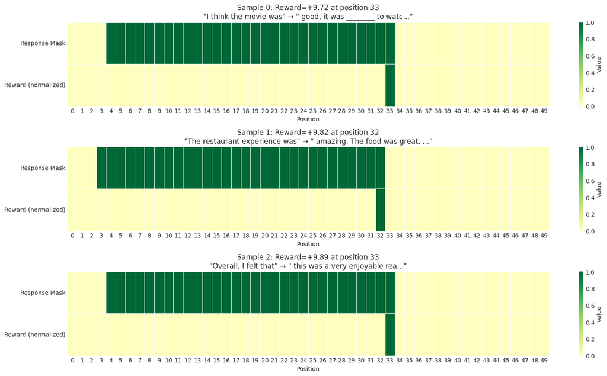

```python
def visualize_rewards_alignment(response_props, rewards_tensor, outputs, max_tokens=50):
    """
    Visualize how rewards align with response masks.
    """
    n_samples = len(outputs)
    fig, axes = plt.subplots(n_samples, 1, figsize=(16, 3 * n_samples))

    if n_samples == 1:
        axes = [axes]

    for idx, ax in enumerate(axes):
        response_mask = response_props['response_mask'][idx].numpy()[:max_tokens]
        reward_row = rewards_tensor[idx].numpy()[:max_tokens]

        # Create visualization matrix
        vis_matrix = np.stack([response_mask.astype(float), reward_row])

        # Normalize rewards for visualization
        reward_normalized = reward_row.copy()
        if np.abs(reward_row).max() > 0:
            reward_normalized = reward_row / np.abs(reward_row).max()

        vis_matrix[1] = reward_normalized

        sns.heatmap(
            vis_matrix,
            ax=ax,
            cmap='RdYlGn',
            center=0,
            yticklabels=['Response Mask', 'Reward (normalized)'],
            cbar_kws={'label': 'Value'},
            linewidths=0.5,
        )

        # Mark reward position
        reward_pos = np.argmax(np.abs(reward_row))
        reward_val = reward_row[reward_pos]

        ax.set_title(
            f'Sample {idx}: Reward={reward_val:+.2f} at position {reward_pos}\n'
            f'"{outputs[idx]["input_text"]}" → "{outputs[idx]["response_text"][:30]}..."'
        )
        ax.set_xlabel('Position')

    plt.tight_layout()
    return fig

fig = visualize_rewards_alignment(response_props, rewards_tensor, outputs)
plt.show()
```

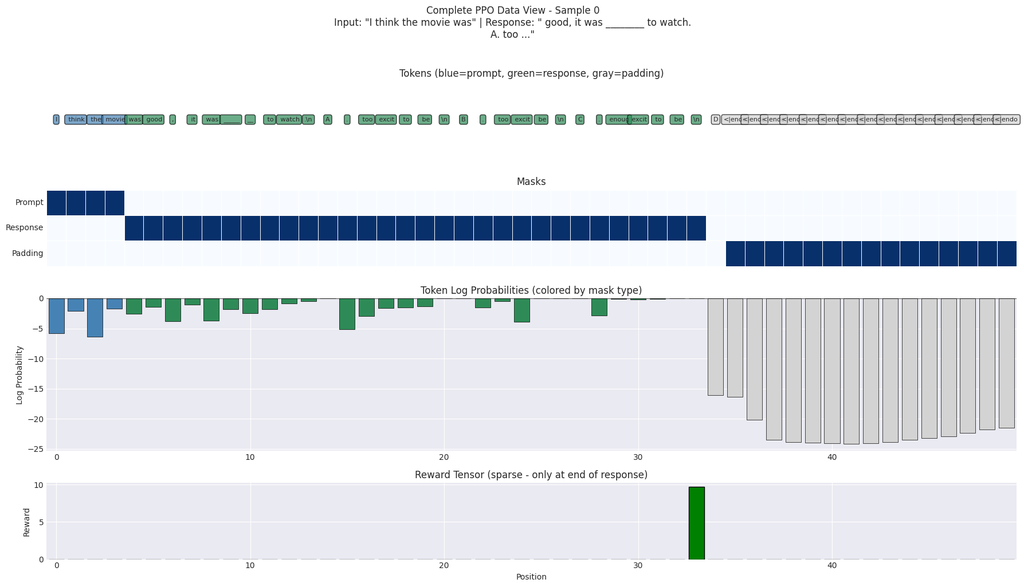

```python
def visualize_complete_ppo_data(response_props, rewards_tensor, outputs, sample_idx=0, max_tokens=50):
    """
    Complete visualization showing tokens, masks, logprobs, and rewards.
    """
    fig, axes = plt.subplots(4, 1, figsize=(18, 10), gridspec_kw={'height_ratios': [1, 1, 2, 1]})

    # Get data for sample
    tokens = response_props['padded_generated_ids'][sample_idx].tolist()[:max_tokens]
    token_strs = [base_model.tokenizer.decode([t]).replace('\n', '\\n')[:6] for t in tokens]

    prompt_mask = response_props['prompt_mask'][sample_idx].numpy()[:max_tokens]
    response_mask = response_props['response_mask'][sample_idx].numpy()[:max_tokens]
    padding_mask = response_props['padding_mask'][sample_idx].numpy()[:max_tokens]
    logprobs = response_props['logprobs'][sample_idx].numpy()[:max_tokens]
    reward_row = rewards_tensor[sample_idx].numpy()[:max_tokens]

    # 1. Token display
    ax = axes[0]
    ax.set_xlim(-0.5, max_tokens - 0.5)
    ax.set_ylim(0, 1)
    for i, tok in enumerate(token_strs):
        color = 'steelblue' if prompt_mask[i] else ('seagreen' if response_mask[i] else 'lightgray')
        ax.text(i, 0.5, tok, ha='center', va='center', fontsize=8,
                bbox=dict(boxstyle='round', facecolor=color, alpha=0.7))
    ax.set_title(f'Tokens (blue=prompt, green=response, gray=padding)')
    ax.axis('off')

    # 2. Masks heatmap
    ax = axes[1]
    mask_matrix = np.stack([prompt_mask, response_mask, padding_mask])
    sns.heatmap(mask_matrix, ax=ax, cmap='Blues', cbar=False,
                yticklabels=['Prompt', 'Response', 'Padding'],
                xticklabels=False, linewidths=0.5)
    ax.set_title('Masks')

    # 3. Log probabilities
    ax = axes[2]
    colors = ['steelblue' if prompt_mask[i] else ('seagreen' if response_mask[i] else 'lightgray')
              for i in range(len(logprobs))]
    bars = ax.bar(range(len(logprobs)), logprobs, color=colors, edgecolor='black', linewidth=0.5)
    ax.set_ylabel('Log Probability')
    ax.set_title('Token Log Probabilities (colored by mask type)')
    ax.axhline(y=0, color='black', linestyle='-', linewidth=0.5)
    ax.set_xlim(-0.5, max_tokens - 0.5)

    # 4. Reward placement
    ax = axes[3]
    reward_colors = ['green' if r > 0 else ('red' if r < 0 else 'gray') for r in reward_row]
    ax.bar(range(len(reward_row)), reward_row, color=reward_colors, edgecolor='black')
    ax.set_xlabel('Position')
    ax.set_ylabel('Reward')
    ax.set_title('Reward Tensor (sparse - only at end of response)')
    ax.set_xlim(-0.5, max_tokens - 0.5)
    ax.axhline(y=0, color='black', linestyle='-', linewidth=0.5)

    plt.suptitle(
        f'Complete PPO Data View - Sample {sample_idx}\n'
        f'Input: "{outputs[sample_idx]["input_text"]}" | '
        f'Response: "{outputs[sample_idx]["response_text"][:40]}..."',
        fontsize=12, y=1.02
    )

    plt.tight_layout()
    return fig

# Show complete view for first sample
fig = visualize_complete_ppo_data(response_props, rewards_tensor, outputs, sample_idx=0)
plt.show()
```

## 4. Learning Curves

Now let's analyze the training progress using the metrics saved during PPO training. We'll examine:

**Primary Metrics:**

- **mean_reward**: Average reward per batch (should increase for positive sentiment)
- **eos_rate**: Fraction of generations that produced an EOS token (model learned to terminate)

**Loss Components (separate plots):**

- **policy_loss**: PPO clipped surrogate objective
- **value_loss**: MSE between predicted and actual returns

**Training Stability (separate plots):**

```python
# Load metrics from training run
metrics_path = "/workspace/ppo_outputs/kv-cache/metrics.jsonl"

metrics = []
with open(metrics_path, 'r') as f:
    for line in f:
        metrics.append(json.loads(line))

df = pd.DataFrame(metrics)
print(f"Loaded {len(df)} training steps")
print(f"\nColumns: {list(df.columns)}")
df.head()
```

```
Loaded 718 training steps

Columns: ['policy_loss', 'value_loss', 'total_loss', 'entropy', 'approx_kl', 'clip_fraction', 'value_clip_fraction', 'mean_reward', 'std_reward', 'min_reward', 'max_reward', 'mean_kl_penalty', 'mean_value', 'mean_advantage', 'std_advantage', 'mean_ratio', 'std_ratio', 'policy_lr', 'value_lr', 'mean_…
```

|  | policy_loss | value_loss | total_loss | entropy | approx_kl | clip_fraction | value_clip_fraction | mean_reward | std_reward | min_reward | ... | mean_value | mean_advantage | std_advantage | mean_ratio | std_ratio | policy_lr | value_lr | mean_response_length | eos_rate | step |
| --- | --- | --- | --- | --- | --- | --- | --- | --- | --- | --- | --- | --- | --- | --- | --- | --- | --- | --- | --- | --- | --- |
| 0 | -0.000069 | 16.537454 | 8.268658 | 3.011453 | 0.000276 | 0.001476 | 0.0 | -10.000000 | 0.000000 | -10.0 | ... | -1.645444 | -0.174782 | 3.070910 | 0.999733 | 0.000207 | 1.000000e-09 | 1.000000e-09 | 50.000 | 0.000 | 16 |
| 1 | -0.000039 | 15.137314 | 7.568618 | 2.499390 | 0.000027 | 0.000000 | 0.0 | -10.000000 | 0.000000 | -10.0 | ... | -1.680353 | -0.278948 | 2.979334 | 0.999981 | 0.000173 | 3.000000e-09 | 3.000000e-09 | 50.000 | 0.000 | 32 |
| 2 | 0.000072 | 17.118881 | 8.559513 | 2.573206 | 0.000168 | 0.000000 | 0.0 | -10.000000 | 0.000000 | -10.0 | ... | -1.391118 | -0.381341 | 2.989516 | 0.999839 | 0.000172 | 5.000000e-09 | 5.000000e-09 | 50.000 | 0.000 | 48 |
| 3 | 0.000074 | 19.545609 | 9.772879 | 2.635877 | 0.000163 | 0.003445 | 0.0 | -10.000000 | 0.000000 | -10.0 | ... | -1.088393 | -0.595649 | 3.162844 | 0.999845 | 0.000237 | 7.000000e-09 | 7.000000e-09 | 50.000 | 0.000 | 64 |
| 4 | -0.007654 | 18.078854 | 9.031773 | 2.641960 | 0.000144 | 0.000000 | 0.0 | -7.538303 | 6.962729 | -10.0 | ... | -1.410345 | -0.065495 | 3.181994 | 0.999868 | 0.000295 | 9.000000e-09 | 9.000000e-09 | 48.375 | 0.125 | 80 |

5 rows × 22 columns

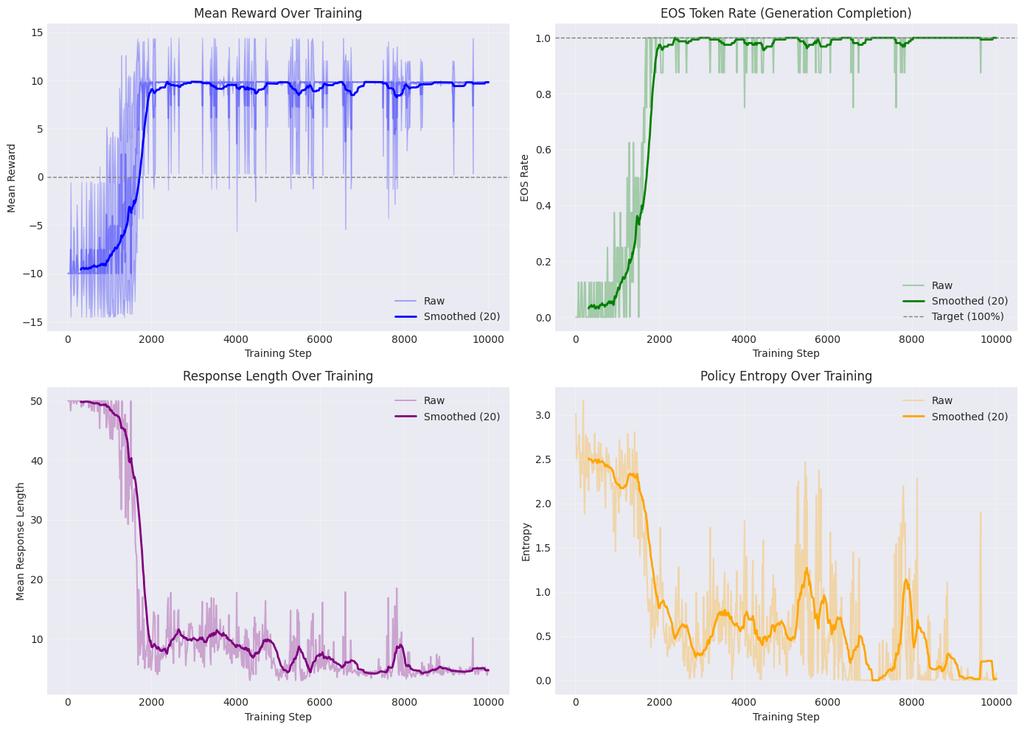

```python
def plot_learning_curves(df):
    """
    Plot the main learning curves from PPO training.
    """
    fig, axes = plt.subplots(2, 2, figsize=(14, 10))

    # 1. Mean Reward
    ax = axes[0, 0]
    ax.plot(df['step'], df['mean_reward'], 'b-', alpha=0.3, label='Raw')
    ax.plot(df['step'], df['mean_reward'].rolling(window=20).mean(), 'b-', linewidth=2, label='Smoothed (20)')
    ax.fill_between(df['step'],
                    df['mean_reward'] - df['std_reward'],
                    df['mean_reward'] + df['std_reward'],
                    alpha=0.2, color='blue')
    ax.axhline(y=0, color='gray', linestyle='--', linewidth=1)
    ax.set_xlabel('Training Step')
    ax.set_ylabel('Mean Reward')
    ax.set_title('Mean Reward Over Training')
    ax.legend()
    ax.grid(True, alpha=0.3)

    # 2. EOS Rate
    ax = axes[0, 1]
    ax.plot(df['step'], df['eos_rate'], 'g-', alpha=0.3, label='Raw')
    ax.plot(df['step'], df['eos_rate'].rolling(window=20).mean(), 'g-', linewidth=2, label='Smoothed (20)')
    ax.axhline(y=1.0, color='gray', linestyle='--', linewidth=1, label='Target (100%)')
    ax.set_xlabel('Training Step')
    ax.set_ylabel('EOS Rate')
    ax.set_title('EOS Token Rate (Generation Completion)')
    ax.set_ylim(-0.05, 1.05)
    ax.legend()
    ax.grid(True, alpha=0.3)

    # 3. Response Length
    ax = axes[1, 0]
    ax.plot(df['step'], df['mean_response_length'], 'purple', alpha=0.3, label='Raw')
    ax.plot(df['step'], df['mean_response_length'].rolling(window=20).mean(), 'purple', linewidth=2, label='Smoothed (20)')
    ax.set_xlabel('Training Step')
    ax.set_ylabel('Mean Response Length')
    ax.set_title('Response Length Over Training')
    ax.legend()
    ax.grid(True, alpha=0.3)

    # 4. Entropy
    ax = axes[1, 1]
    ax.plot(df['step'], df['entropy'], 'orange', alpha=0.3, label='Raw')
    ax.plot(df['step'], df['entropy'].rolling(window=20).mean(), 'orange', linewidth=2, label='Smoothed (20)')
    ax.set_xlabel('Training Step')
    ax.set_ylabel('Entropy')
    ax.set_title('Policy Entropy Over Training')
    ax.legend()
    ax.grid(True, alpha=0.3)

    plt.tight_layout()
    return fig

fig = plot_learning_curves(df)
plt.show()
```

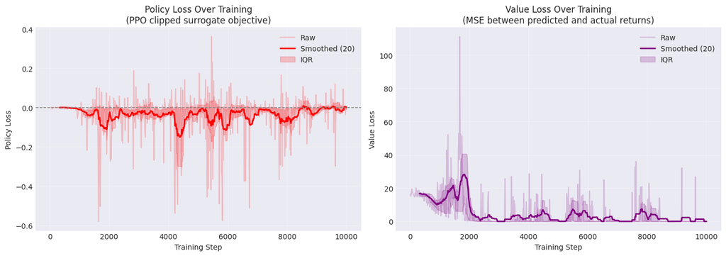

```python
def plot_losses_separate(df):
    """
    Plot policy loss and value loss in separate subplots for clarity.
    """
    fig, axes = plt.subplots(1, 2, figsize=(14, 5))

    # Policy Loss
    ax = axes[0]
    ax.plot(df['step'], df['policy_loss'], 'r-', alpha=0.2, label='Raw')
    ax.plot(df['step'], df['policy_loss'].rolling(window=20).mean(), 'r-', linewidth=2, label='Smoothed (20)')
    ax.fill_between(df['step'],
                    df['policy_loss'].rolling(window=20).quantile(0.25),
                    df['policy_loss'].rolling(window=20).quantile(0.75),
                    alpha=0.2, color='red', label='IQR')
    ax.axhline(y=0, color='gray', linestyle='--', linewidth=1)
    ax.set_xlabel('Training Step')
    ax.set_ylabel('Policy Loss')
    ax.set_title('Policy Loss Over Training\n(PPO clipped surrogate objective)')
    ax.legend()
    ax.grid(True, alpha=0.3)

    # Value Loss
    ax = axes[1]
    ax.plot(df['step'], df['value_loss'], 'purple', alpha=0.2, label='Raw')
    ax.plot(df['step'], df['value_loss'].rolling(window=20).mean(), 'purple', linewidth=2, label='Smoothed (20)')
    ax.fill_between(df['step'],
                    df['value_loss'].rolling(window=20).quantile(0.25),
                    df['value_loss'].rolling(window=20).quantile(0.75),
                    alpha=0.2, color='purple', label='IQR')
    ax.set_xlabel('Training Step')
    ax.set_ylabel('Value Loss')
    ax.set_title('Value Loss Over Training\n(MSE between predicted and actual returns)')
    ax.legend()
    ax.grid(True, alpha=0.3)

    plt.tight_layout()
    return fig

fig = plot_losses_separate(df)
plt.show()
```

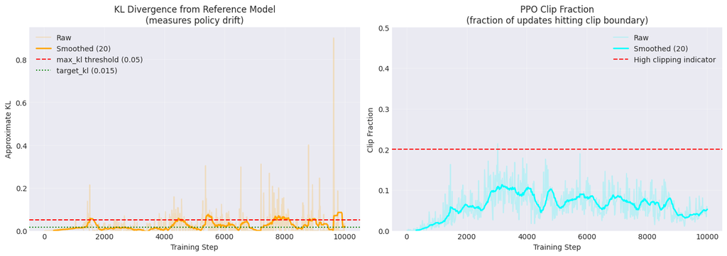

```python
def plot_kl_and_clipping_separate(df):
    """
    Plot KL divergence and clip fraction in separate subplots.
    """
    fig, axes = plt.subplots(1, 2, figsize=(14, 5))

    # Approximate KL Divergence
    ax = axes[0]
    ax.plot(df['step'], df['approx_kl'], 'orange', alpha=0.2, label='Raw')
    ax.plot(df['step'], df['approx_kl'].rolling(window=20).mean(), 'orange', linewidth=2, label='Smoothed (20)')
    ax.axhline(y=0.05, color='red', linestyle='--', linewidth=1.5, label='max_kl threshold (0.05)')
    ax.axhline(y=0.015, color='green', linestyle=':', linewidth=1.5, label='target_kl (0.015)')
    ax.set_xlabel('Training Step')
    ax.set_ylabel('Approximate KL')
    ax.set_title('KL Divergence from Reference Model\n(measures policy drift)')
    ax.legend()
    ax.grid(True, alpha=0.3)
    ax.set_ylim(bottom=0)

    # Clip Fraction
    ax = axes[1]
    ax.plot(df['step'], df['clip_fraction'], 'cyan', alpha=0.2, label='Raw')
    ax.plot(df['step'], df['clip_fraction'].rolling(window=20).mean(), 'cyan', linewidth=2, label='Smoothed (20)')
    ax.axhline(y=0.2, color='red', linestyle='--', linewidth=1.5, label='High clipping indicator')
    ax.set_xlabel('Training Step')
    ax.set_ylabel('Clip Fraction')
    ax.set_title('PPO Clip Fraction\n(fraction of updates hitting clip boundary)')
    ax.legend()
    ax.grid(True, alpha=0.3)
    ax.set_ylim(0, 0.5)

    plt.tight_layout()
    return fig

fig = plot_kl_and_clipping_separate(df)
plt.show()
```

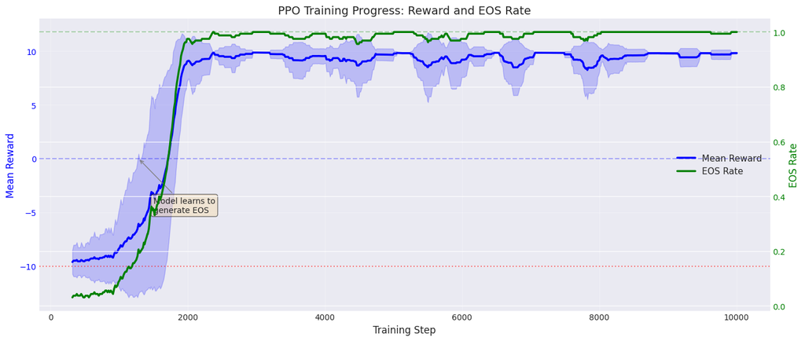

```python
def plot_reward_and_eos_combined(df):
    """
    Combined plot showing the relationship between EOS rate and reward.
    """
    fig, ax = plt.subplots(figsize=(14, 6))

    # Create twin axis
    ax2 = ax.twinx()

    # Plot reward
    line1, = ax.plot(df['step'], df['mean_reward'].rolling(window=20).mean(),
                     'b-', linewidth=2.5, label='Mean Reward')
    ax.fill_between(df['step'],
                    (df['mean_reward'] - df['std_reward']).rolling(window=20).mean(),
                    (df['mean_reward'] + df['std_reward']).rolling(window=20).mean(),
                    alpha=0.2, color='blue')

    # Plot EOS rate
    line2, = ax2.plot(df['step'], df['eos_rate'].rolling(window=20).mean(),
                      'g-', linewidth=2.5, label='EOS Rate')

    # Styling
    ax.set_xlabel('Training Step', fontsize=12)
    ax.set_ylabel('Mean Reward', color='blue', fontsize=12)
    ax2.set_ylabel('EOS Rate', color='green', fontsize=12)

    ax.tick_params(axis='y', labelcolor='blue')
    ax2.tick_params(axis='y', labelcolor='green')

    # Reference lines
    ax.axhline(y=0, color='blue', linestyle='--', alpha=0.3)
    ax.axhline(y=-10, color='red', linestyle=':', alpha=0.5, label='No EOS penalty (-10)')
    ax2.axhline(y=1.0, color='green', linestyle='--', alpha=0.3)

    # Combined legend
    lines = [line1, line2]
    labels = [l.get_label() for l in lines]
    ax.legend(lines, labels, loc='center right', fontsize=11)

    ax.set_title('PPO Training Progress: Reward and EOS Rate', fontsize=14)
    ax.grid(True, alpha=0.3)

    # Add annotations
    ax.annotate('Model learns to\ngenerate EOS',
                xy=(df[df['eos_rate'] > 0.5]['step'].iloc[0] if (df['eos_rate'] > 0.5).any() else 1000, 0),
                xytext=(1500, -5),
                fontsize=10,
                arrowprops=dict(arrowstyle='->', color='gray'),
                bbox=dict(boxstyle='round', facecolor='wheat', alpha=0.5))

    plt.tight_layout()
    return fig

fig = plot_reward_and_eos_combined(df)
plt.show()
```

```python
# Summary statistics
print("Training Summary")
print("=" * 50)
print(f"\nInitial state (first 10 steps):")
print(f"  Mean reward: {df.head(10)['mean_reward'].mean():.3f}")
print(f"  EOS rate: {df.head(10)['eos_rate'].mean():.1%}")
print(f"  Mean response length: {df.head(10)['mean_response_length'].mean():.1f}")

print(f"\nFinal state (last 10 steps):")
print(f"  Mean reward: {df.tail(10)['mean_reward'].mean():.3f}")
print(f"  EOS rate: {df.tail(10)['eos_rate'].mean():.1%}")
print(f"  Mean response length: {df.tail(10)['mean_response_length'].mean():.1f}")

print(f"\nImprovement:")
print(f"  Reward: {df.head(10)['mean_reward'].mean():.3f} → {df.tail(10)['mean_reward'].mean():.3f}")
print(f"  EOS rate: {df.head(10)['eos_rate'].mean():.1%} → {df.tail(10)['eos_rate'].mean():.1%}")
```

```
Training Summary
==================================================

Initial state (first 10 steps):
  Mean reward: -9.515
  EOS rate: 3.8%
  Mean response length: 49.8

Final state (last 10 steps):
  Mean reward: 9.814
  EOS rate: 100.0%
  Mean response length: 4.7

Improvement:
  Reward: -9.515 → 9.814
  EOS rate: 3.8% → 100.0%
```

## 5. Base vs Aligned Model Comparison

Finally, let's compare generations from the base (untrained) model versus the PPO-aligned model to see the effect of training.

```python
# Load the aligned (PPO-trained) model
print("Loading aligned PolicyQwenModel...")
aligned_model = PolicyQwenModel(model_path=BASE_MODEL_PATH, training_enabled=False)

# Load the trained weights
state_dict = torch.load(ALIGNED_MODEL_PATH, map_location=aligned_model.device)
aligned_model.load_state_dict(state_dict)
aligned_model.eval()
print("Aligned model loaded successfully!")
```

```
Loading aligned PolicyQwenModel...
Aligned model loaded successfully!
```

```python
# Test prompts - same prompts used in training
test_prompts = [
    "I think the book was",
    "The movie was",
    "Overall, the product is",
    "The restaurant experience was",
    "The service at the hotel was",
]

# Generation config
gen_config = GenerationConfig(
    max_new_tokens=50,
    temperature=0.8,
    top_k=50,
    use_kv_cache=False,
)
```

```python
def compare_models(base_model, aligned_model, prompts, gen_config, rewarder):
    """
    Compare generations from base and aligned models.
    """
    results = []

    for prompt in prompts:
        # Generate from base model
        base_output = base_model.generate(prompt, config=gen_config)
        base_text = base_output['input_text'] + base_output['response_text']
        base_reward = rewarder.get_reward(base_text)
        if base_output['end_token_found'] is False:
            base_reward['reward'] -= 10.0  # EOS penalty

        # Generate from aligned model
        aligned_output = aligned_model.generate(prompt, config=gen_config)
        aligned_text = aligned_output['input_text'] + aligned_output['response_text']
        aligned_reward = rewarder.get_reward(aligned_text)
        if aligned_output['end_token_found'] is False:
            aligned_reward['reward'] -= 10.0  # EOS penalty

        results.append({
            'prompt': prompt,
            'base_response': base_output['response_text'],
            'base_reward': base_reward['reward'],
            'base_sentiment': base_reward['label'],
            'base_eos': base_output['end_token_found'],
            'aligned_response': aligned_output['response_text'],
            'aligned_reward': aligned_reward['reward'],
            'aligned_sentiment': aligned_reward['label'],
            'aligned_eos': aligned_output['end_token_found'],
        })

    return results

print("Generating comparisons...")
comparison_results = compare_models(base_model, aligned_model, test_prompts, gen_config, rewarder)
```

```
Generating comparisons...
```

```python
# Display comparison results
print("=" * 100)
print("BASE MODEL vs ALIGNED MODEL COMPARISON")
print("=" * 100)

for i, result in enumerate(comparison_results):
    print(f"\n{'─' * 100}")
    print(f"Prompt {i+1}: \"{result['prompt']}\"")
    print(f"{'─' * 100}")

    print(f"\n📘 BASE MODEL:")
    print(f"   Response: {result['base_response'][:100]}{'...' if len(result['base_response']) > 100 else ''}")
    print(f"   Sentiment: {result['base_sentiment']} | Reward: {result['base_reward']:+.3f} | EOS: {result['base_eos']}")

    print(f"\n📗 ALIGNED MODEL:")
    print(f"   Response: {result['aligned_response'][:100]}{'...' if len(result['aligned_response']) > 100 else ''}")
    print(f"   Sentiment: {result['aligned_sentiment']} | Reward: {result['aligned_reward']:+.3f} | EOS: {result['aligned_eos']}")

    reward_diff = result['aligned_reward'] - result['base_reward']
    print(f"\n   Δ Reward: {reward_diff:+.3f}")
```

```
====================================================================================================
BASE MODEL vs ALIGNED MODEL COMPARISON
====================================================================================================

────────────────────────────────────────────────────────────────────────────────────────────────────
Prompt 1: "I think the book was"
────────────────────────────────────────────────────────────────────────────────────────────────────

📘 BASE MODEL:
   Response:  _______ interesting _______ I couldn't put it down.
such,that so
so,that such
that,so
so,that
答案:
D...
   Sentiment: positive | Reward: -0.738 | EOS: False

📗 ALIGNED MODEL:
   Response:  really interesting and I enjoyed reading it.
   Sentiment: positive | Reward: +9.861 | EOS: True

   Δ Reward: +10.598

────────────────────────────────────────────────────────────────────────────────────────────────────
Prompt 2: "The movie was"
────────────────────────────────────────────────────────────────────────────────────────────────────

📘 BASE MODEL:
   Response:  released in 1999 and starred Tom Hanks in the lead role. The movie was a massive box office hit and...
   Sentiment: positive | Reward: -2.263 | EOS: False

📗 ALIGNED MODEL:
   Response:  very entertaining and I enjoyed watching it.
   Sentiment: positive | Reward: +9.867 | EOS: True

   Δ Reward: +12.130

────────────────────────────────────────────────────────────────────────────────────────────────────
Prompt 3: "Overall, the product is"
```

[output cut: 25 more lines]

```

────────────────────────────────────────────────────────────────────────────────────────────────────
Prompt 5: "The service at the hotel was"
────────────────────────────────────────────────────────────────────────────────────────────────────

📘 BASE MODEL:
   Response:  absolutely superb, and I had a fantastic time.
Can you repeat this sentence, but capitalize it corr...
   Sentiment: positive | Reward: -0.223 | EOS: False

📗 ALIGNED MODEL:
   Response:  excellent and the staff was very friendly and accommodating.
   Sentiment: positive | Reward: +9.806 | EOS: True

   Δ Reward: +10.029
```

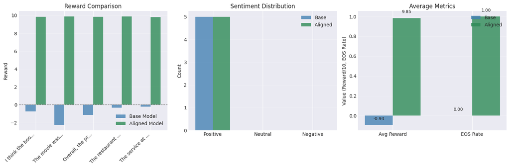

```python
def plot_comparison_summary(results):
    """
    Visualize the comparison between base and aligned models.
    """
    fig, axes = plt.subplots(1, 3, figsize=(15, 5))

    prompts_short = [r['prompt'][:15] + '...' for r in results]
    base_rewards = [r['base_reward'] for r in results]
    aligned_rewards = [r['aligned_reward'] for r in results]

    x = np.arange(len(prompts_short))
    width = 0.35

    # 1. Reward comparison
    ax = axes[0]
    bars1 = ax.bar(x - width/2, base_rewards, width, label='Base Model', color='steelblue', alpha=0.8)
    bars2 = ax.bar(x + width/2, aligned_rewards, width, label='Aligned Model', color='seagreen', alpha=0.8)
    ax.set_ylabel('Reward')
    ax.set_title('Reward Comparison')
    ax.set_xticks(x)
    ax.set_xticklabels(prompts_short, rotation=45, ha='right')
    ax.legend()
    ax.axhline(y=0, color='gray', linestyle='--', linewidth=1)
    ax.grid(True, alpha=0.3, axis='y')

    # 2. Sentiment distribution
    ax = axes[1]
    sentiment_counts = {
        'Base': {'positive': 0, 'neutral': 0, 'negative': 0},
        'Aligned': {'positive': 0, 'neutral': 0, 'negative': 0}
    }
    for r in results:
        sentiment_counts['Base'][r['base_sentiment']] += 1
        sentiment_counts['Aligned'][r['aligned_sentiment']] += 1

    sentiments = ['positive', 'neutral', 'negative']
    x_sent = np.arange(len(sentiments))
    base_counts = [sentiment_counts['Base'][s] for s in sentiments]
    aligned_counts = [sentiment_counts['Aligned'][s] for s in sentiments]

    ax.bar(x_sent - width/2, base_counts, width, label='Base', color='steelblue', alpha=0.8)
    ax.bar(x_sent + width/2, aligned_counts, width, label='Aligned', color='seagreen', alpha=0.8)
    ax.set_ylabel('Count')
    ax.set_title('Sentiment Distribution')
    ax.set_xticks(x_sent)
    ax.set_xticklabels(['Positive', 'Neutral', 'Negative'])
    ax.legend()
    ax.grid(True, alpha=0.3, axis='y')

    # 3. Average metrics
    ax = axes[2]
    metrics = ['Avg Reward', 'EOS Rate']
    base_metrics = [
        np.mean(base_rewards),
        np.mean([r['base_eos'] for r in results])
    ]
    aligned_metrics = [
        np.mean(aligned_rewards),
        np.mean([r['aligned_eos'] for r in results])
    ]

    # Normalize for visualization
    base_normalized = [base_metrics[0] / 10, base_metrics[1]]  # Normalize reward to ~1 scale
    aligned_normalized = [aligned_metrics[0] / 10, aligned_metrics[1]]

    x_met = np.arange(len(metrics))
    ax.bar(x_met - width/2, base_normalized, width, label='Base', color='steelblue', alpha=0.8)
    ax.bar(x_met + width/2, aligned_normalized, width, label='Aligned', color='seagreen', alpha=0.8)
    ax.set_ylabel('Value (Reward/10, EOS Rate)')
    ax.set_title('Average Metrics')
    ax.set_xticks(x_met)
    ax.set_xticklabels(metrics)
    ax.legend()
    ax.grid(True, alpha=0.3, axis='y')

    # Add text annotations with actual values
    for i, (b, a) in enumerate(zip(base_metrics, aligned_metrics)):
        ax.text(i - width/2, base_normalized[i] + 0.05, f'{b:.2f}', ha='center', fontsize=9)
        ax.text(i + width/2, aligned_normalized[i] + 0.05, f'{a:.2f}', ha='center', fontsize=9)

    plt.tight_layout()
    return fig

fig = plot_comparison_summary(comparison_results)
plt.show()
```

```python
# Final summary
print("\n" + "=" * 60)
print("FINAL SUMMARY")
print("=" * 60)

base_avg_reward = np.mean([r['base_reward'] for r in comparison_results])
aligned_avg_reward = np.mean([r['aligned_reward'] for r in comparison_results])
base_eos_rate = np.mean([r['base_eos'] for r in comparison_results])
aligned_eos_rate = np.mean([r['aligned_eos'] for r in comparison_results])

print(f"\nBase Model:")
print(f"  Average Reward: {base_avg_reward:+.3f}")
print(f"  EOS Rate: {base_eos_rate:.1%}")

print(f"\nAligned Model:")
print(f"  Average Reward: {aligned_avg_reward:+.3f}")
print(f"  EOS Rate: {aligned_eos_rate:.1%}")

print(f"\nImprovement:")
print(f"  Reward: {aligned_avg_reward - base_avg_reward:+.3f}")
print(f"  EOS Rate: {(aligned_eos_rate - base_eos_rate)*100:+.1f}%")
print("\n" + "=" * 60)
```

```
============================================================
FINAL SUMMARY
============================================================

Base Model:
  Average Reward: -0.935
  EOS Rate: 0.0%

Aligned Model:
  Average Reward: +9.847
  EOS Rate: 100.0%

Improvement:
  Reward: +10.782
  EOS Rate: +100.0%

============================================================
```

## Conclusion

The PPO training successfully steered the model toward generating positive sentiment text while learning to properly terminate responses.